# COVID-19_Superspreading

Katie Gostic

3/13/2020

## To what extent can we reduce R by focusing on reductions in superspreading, rather than attempting to prevent within-household transmission?

** [Link to Google Doc Draft](https://docs.google.com/document/d/1YbamXMQHSTyJ6kY-9tAIA4W8SeRxAqz3KpvYV7CEXls/edit?usp=sharing) **

** [Link to dispersion paramter sources](https://docs.google.com/spreadsheets/d/14BZdeISQBdA5JrkR0Q8qFfVoQxQH3Z4NMbW5nDxl2bw/edit?usp=sharing) **

- China stopped the spread using extreme authoritarian measures to prevent within-household transmission
- But we know that stopping superspreading should easier, and could substantially bring down Re

Here, we consider potential reductions in Re if control measures are able to move 50% of superspreaders (those tranmitting >= 7 new infections) into the non-superspreading portion of the offspring distribution.

### Simulate offspring distributions in the absence of control

Assume R0 = 2.5, and consider k = 1, .5, 0.1.

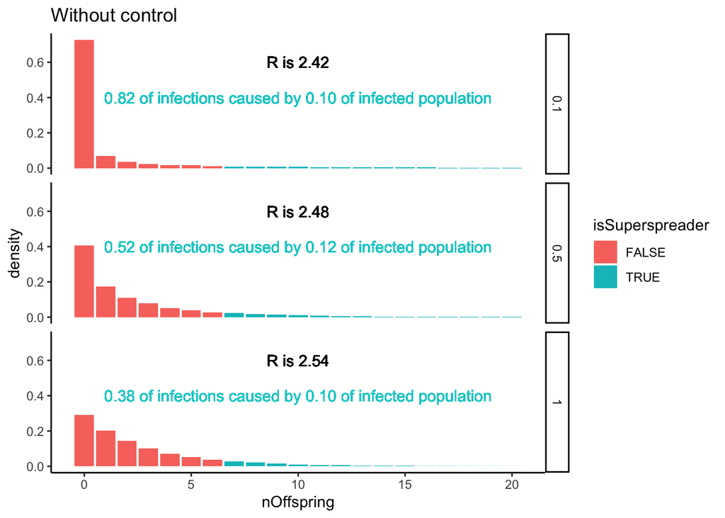

```r
## Write a function to simulate offspring distributions in the absence of control
get_offspring_dist = function(R0, k){
  data.frame(dispersion = k,
             nOffspring = rnbinom(n = nsim, size = k, mu = R0))
}

## Simulate offspring distributions when dispersion parameter is 1, .5 and .1
lapply(c(1, .5, .1), function(dd) get_offspring_dist(2.5, dd)) %>%
  bind_rows() -> sims


sims %>% group_by(dispersion) %>%
  mutate(R = mean(nOffspring)) %>%
  ungroup() %>% group_by(dispersion, nOffspring) %>%
  summarise(dens = n()/nsim,
            R = unique(R)) %>%
  ungroup() %>% group_by(dispersion) %>%
  mutate(isSuperspreader = nOffspring>=7,
         dIs = sum(dens[isSuperspreader]),
         dDs = sum((dens*nOffspring)[isSuperspreader]/sum(dens*nOffspring))) %>%
  ggplot()+
  geom_bar(aes(x = nOffspring, y = dens, fill = isSuperspreader), stat = 'identity')+
  facet_grid(dispersion~.) +
  xlim(c(-.5, 20.5)) +
  ylab('density') +
  geom_text(aes(x = 10, y = .6, label = sprintf('R is %2.2f', R))) +
    geom_text(aes(x = 10, y = .4, label = sprintf('%2.2f of infections caused by %2.2f of infected population', dDs, dIs)), color = 'cyan3') +
  theme_classic()+
  ggtitle('Without control')
```

Fig. 1. Fraction of infections caused by superspreaders vs. non-superspreaders. Arbitrarily define superspreaders as those causing 7 or more new infections. Panels show three candidate values for the negative binomial dispersion paramter, k. All plots assume R0 = 2.5.

### Modify offspring distributions in the presence of control

Assume control prevents 50% of superspreading events (those causing >= 7 new infections) Reassign controlled superspreaders a new number of offspring, drawn from a truncated negative binomial with the same paramters as the original simulation

```r
## ------------ IMPLEMENT CONTROL -------------- ##
## Define superspreader as anyone who causes 7 or more infections. See what happens to R0 if we move 50% of superspreaders into the non-superspreader category.
## Do this by sampling from a truncated negative binomial distribution with paramters R0 and k, and max value (threshold - 1)
get_reduced_r0 = function(origR0s, k, R0, superThreshold = 7){
   isSuperspreader = origR0s >= superThreshold
   toReplace = isSuperspreader & (runif(length(isSuperspreader)) > .5) ## Replace half of superspreaders
   newR0s = origR0s
   newR0s[toReplace] = sample(0:(superThreshold-1), size = sum(toReplace), replace = TRUE, prob = dnbinom(0:(superThreshold-1), size = k, mu = R0)/sum(dnbinom(0:(superThreshold-1), size = k, mu = R0)))
   newR0s
}
#get_reduced_r0(origR0s = 1:100, k = .5, R0 = 2.5)

sims %>% ungroup() %>%
  group_by(dispersion) %>%
  mutate(reducedOffspring = get_reduced_r0(nOffspring, k = unique(dispersion), R0 = 2.5, superThreshold = 7)) -> simWControl
```

### Calculate the mean number of offpsring in the presence/absence of control

(R0 in the absence of control, R in the presence of control)

```r
## Get the expected number of cases caused by each infectious person with and without control
## Should be R0 without control
simWControl %>%
  group_by(dispersion) %>%
  summarise(mean = mean(nOffspring),
            reducedMean = mean(reducedOffspring))
```

```
## # A tibble: 3 x 3
##   dispersion  mean reducedMean
##        <dbl> <dbl>       <dbl>
## 1        0.1  2.42        1.44
## 2        0.5  2.48        1.92
## 3        1    2.54        2.13
```

–> If k is low, we can dramatically reduce R just by preventing 50% of superspreading events

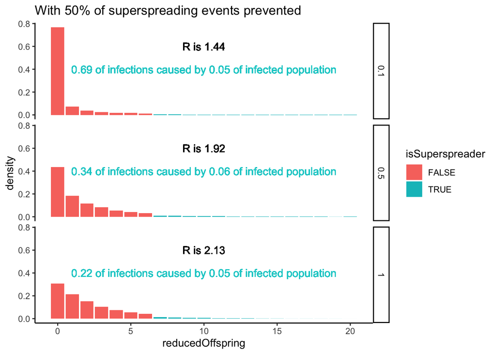

```r
simWControl %>% group_by(dispersion) %>%
  mutate(R = mean(reducedOffspring)) %>%
  ungroup() %>% group_by(dispersion, reducedOffspring) %>%
  summarise(dens = n()/nsim,
            R = unique(R)) %>%
  ungroup() %>% group_by(dispersion) %>%
  mutate(isSuperspreader = reducedOffspring>=7,
         dIs = sum(dens[isSuperspreader]),
         dDs = sum((dens*reducedOffspring)[isSuperspreader]/sum(dens*reducedOffspring))) %>%
  ggplot()+
  geom_bar(aes(x = reducedOffspring, y = dens, fill = isSuperspreader), stat = 'identity')+
  facet_grid(dispersion~.) +
  xlim(c(-.5, 20.5)) +
  ylab('density') +
  geom_text(aes(x = 10, y = .6, label = sprintf('R is %2.2f', R))) +
    geom_text(aes(x = 10, y = .4, label = sprintf('%2.2f of infections caused by %2.2f of infected population', dDs, dIs)), color = 'cyan3') +
  theme_classic()+
  ggtitle('With 50% of superspreading events prevented')
```

Fig. 2. Fraction of infections caused by superspreaders vs. non-superspreaders. Arbitrarily define superspreaders as those causing 7 or more new infections. With control, reassign 50% of individuals with >=7 offspring to a lower number of offspring, randomly drawn from a truncated negative binomial with maximum value 6. Panels show three candidate values for the negative binomial dispersion paramter, k. All plots assume R0 = 2.5.

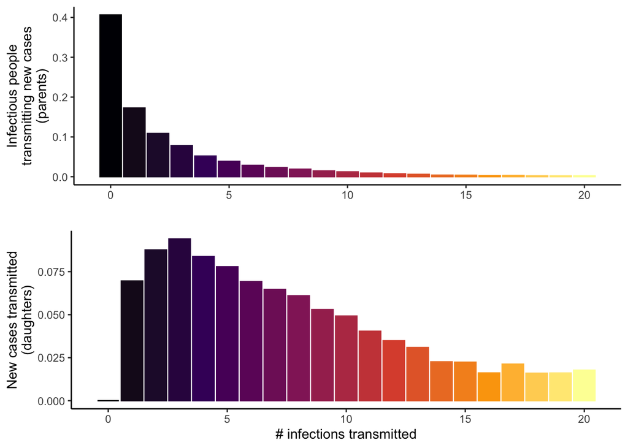

```r
sims %>%
  filter(dispersion == .5) %>%
  ungroup() %>% group_by(nOffspring) %>%
  summarise(dens = n()/nsim) %>%
  ungroup() %>%
  mutate(fracNew = (dens*nOffspring)/sum(dens*nOffspring)) %>%
  ggplot()+
  geom_bar(aes(x = nOffspring, y = dens, fill = nOffspring, color = nOffspring), stat = 'identity')+
  xlim(c(-.5, 20.5)) +
  ylab('Infectious people\ntransmitting new cases\n(parents)') +
  xlab('')+
  #geom_text(aes(x = 10, y = .6, label = sprintf('R is %2.2f', R))) +
    #geom_text(aes(x = 10, y = .4, label = sprintf('%2.2f of infections caused by %2.2f of infected population', dDs, dIs)), color = 'cyan3') +
  theme_classic()+
  #ggtitle('Parent infections') +
    scale_color_viridis_c(option = 'inferno', guide = FALSE) +
  scale_fill_viridis_c(option = 'inferno', guide = FALSE) -> aa


sims %>%
  filter(dispersion == .5) %>%
  ungroup() %>% group_by(nOffspring) %>%
  summarise(dens = n()/nsim) %>%
  ungroup() %>%
  mutate(fracNew = (dens*nOffspring)/sum(dens*nOffspring)) %>%
  ggplot()+
  geom_bar(aes(x = nOffspring, y = fracNew, fill = nOffspring, color = nOffspring), stat = 'identity')+
  xlim(c(-.5, 20.5)) +
  ylab('New cases transmitted\n(daughters)') +
  xlab('# infections transmitted')+
  #geom_text(aes(x = 10, y = .6, label = sprintf('R is %2.2f', R))) +
    #geom_text(aes(x = 10, y = .4, label = sprintf('%2.2f of infections caused by %2.2f of infected population', dDs, dIs)), color = 'cyan3') +
  theme_classic()+
  #ggtitle('Daughter infections') +
  scale_color_viridis_c(option = 'inferno', guide = FALSE) +
  scale_fill_viridis_c(option = 'inferno', guide = FALSE) -> bb

gridExtra::grid.arrange(aa, bb, nrow = 2)
```

Fig. 3. Just a few superspreaders (top), cause the majority of new infections (bottom). Here, k = 0.5.